# Hands_On_lab_1

Jeff Shamp

1/28/2020

Pittsburgh is known locally as the city of bridges, the construction of the bridges are a result of city’s location at the confluence of three major rivers; the Allegheny, the Monongahela, and the Ohio. Pittsburgh was a steel town for much of it’s history so as the city grew during the industrial era, more and more bridges were need to connect residents across the rivers to the steel mills and factories.

```r
library(plyr)
library(RCurl)
data <- getURL("https://archive.ics.uci.edu/ml/machine-learning-databases/bridges/bridges.data.version1")
df <- data.frame(read.csv(text = data, header = FALSE))
head(df)
```

```
##   V1 V2 V3   V4       V5   V6 V7 V8      V9  V10    V11 V12  V13
## 1 E1  M  3 1818  HIGHWAY    ?  2  N THROUGH WOOD  SHORT   S WOOD
## 2 E2  A 25 1819  HIGHWAY 1037  2  N THROUGH WOOD  SHORT   S WOOD
## 3 E3  A 39 1829 AQUEDUCT    ?  1  N THROUGH WOOD      ?   S WOOD
## 4 E5  A 29 1837  HIGHWAY 1000  2  N THROUGH WOOD  SHORT   S WOOD
## 5 E6  M 23 1838  HIGHWAY    ?  2  N THROUGH WOOD      ?   S WOOD
## 6 E7  A 27 1840  HIGHWAY  990  2  N THROUGH WOOD MEDIUM   S WOOD
```

The data columns do not come with names. We will need to rename them.

```r
df<-rename(df, c("V1"="Id", "V2"="river", "V3"="location","V4"="erected","V5"="purpose",
             "V6"="length", "V7"="lanes","V8"="clear_g","V9"="t_or_d", "V10"="material",
             "V11"="span","V12"="rel", "V13"="type"))
head(df)
```

```
##   Id river location erected  purpose length lanes clear_g  t_or_d material
## 1 E1     M        3    1818  HIGHWAY      ?     2       N THROUGH     WOOD
## 2 E2     A       25    1819  HIGHWAY   1037     2       N THROUGH     WOOD
## 3 E3     A       39    1829 AQUEDUCT      ?     1       N THROUGH     WOOD
## 4 E5     A       29    1837  HIGHWAY   1000     2       N THROUGH     WOOD
## 5 E6     M       23    1838  HIGHWAY      ?     2       N THROUGH     WOOD
## 6 E7     A       27    1840  HIGHWAY    990     2       N THROUGH     WOOD
##     span rel type
## 1  SHORT   S WOOD
## 2  SHORT   S WOOD
## 3      ?   S WOOD
## 4  SHORT   S WOOD
## 5      ?   S WOOD
## 6 MEDIUM   S WOOD
```

## Age of Bridges

Now let’s look at the age range of the bridges in Pittsburgh. I suspect most were built between 1850 and 1950.

```r
summary(df$erected)
```

```
##    Min. 1st Qu.  Median    Mean 3rd Qu.    Max.
##    1818    1884    1903    1905    1928    1986
```

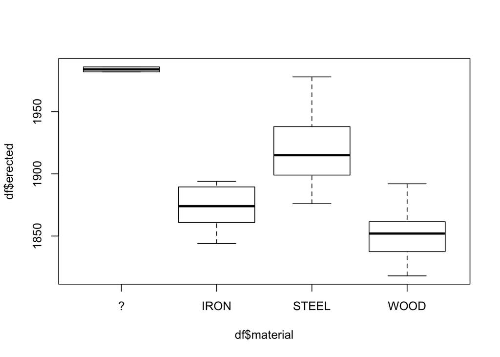

```r
boxplot(df$erected ~ df$material)
```

## Construction Materials

Below are building materials for each bridge

```r
summary(df$material)
```

```
##     ?  IRON STEEL  WOOD
##     2    11    79    16
```

While there are a few unkowns, the primary materials are Iron, Steel, and Wood. I would imagine that most of the very old bridges are Iron or Wood, and that the steel bridges were likely built after 1920. We can subset build year with material type to if that’s true.

```r
material_sub<- subset(df, material=="STEEL")
summary(material_sub$erected)
```

```
##    Min. 1st Qu.  Median    Mean 3rd Qu.    Max.
##    1876    1899    1915    1919    1938    1978
```

So the first steel bridge was built in 1876 and the last steel bridge was built in 1978. 1978 was not the last bridge built in Pittsburgh.

```r
last_bridge <- subset(df, erected > 1978)
summary(last_bridge$material)
```

```
##     ?  IRON STEEL  WOOD
##     2     0     0     0
```

The two unknown material are the most recent, strange. I guess they must a mix of materials rather than a clear iron, steel, or wood.

## Bridges to North Shore

```r
north_shore<-subset(df, river=="A")
summary(north_shore$erected)
```

```
##    Min. 1st Qu.  Median    Mean 3rd Qu.    Max.
##    1819    1866    1900    1898    1926    1986
```

One the first bridges and last one were built over the Allegheny River and connecting the north shore neighborhoods to the main city.